# Irene Data Analysis

Mwaura Patrick

1/29/2021

This analysis is being done at the request of the researcher

### Summary of the data

View the summary of the data

Summary

| skim_type | skim_variable | n_missing | complete_rate | character.min | character.max | character.empty | character.n_unique | character.whitespace | numeric.mean | numeric.sd | numeric.p0 | numeric.p25 | numeric.p50 | numeric.p75 | numeric.p100 | numeric.hist |
| --- | --- | --- | --- | --- | --- | --- | --- | --- | --- | --- | --- | --- | --- | --- | --- | --- |
| character | ISOLATE_ID | 0 | 1.0000000 | 4 | 6 | 0 | 282 | 0 | NA | NA | NA | NA | NA | NA | NA | NA |
| character | Community | 0 | 1.0000000 | 8 | 13 | 0 | 4 | 0 | NA | NA | NA | NA | NA | NA | NA | NA |
| character | Boma | 267 | 0.1158940 | 6 | 16 | 0 | 10 | 0 | NA | NA | NA | NA | NA | NA | NA | NA |
| character | LPS | 0 | 1.0000000 | 9 | 9 | 0 | 2 | 0 | NA | NA | NA | NA | NA | NA | NA | NA |
| character | AGE | 0 | 1.0000000 | 5 | 9 | 0 | 3 | 0 | NA | NA | NA | NA | NA | NA | NA | NA |
| character | Gender | 0 | 1.0000000 | 4 | 6 | 0 | 2 | 0 | NA | NA | NA | NA | NA | NA | NA | NA |
| character | Sample_Type | 0 | 1.0000000 | 10 | 10 | 0 | 1 | 0 | NA | NA | NA | NA | NA | NA | NA | NA |
| character | Transport_media | 0 | 1.0000000 | 10 | 10 | 0 | 1 | 0 | NA | NA | NA | NA | NA | NA | NA | NA |
| character | mo | 0 | 1.0000000 | 6 | 16 | 0 | 2 | 0 | NA | NA | NA | NA | NA | NA | NA | NA |
| character | Colony_Morphology | 169 | 0.4403974 | 29 | 70 | 0 | 41 | 0 | NA | NA | NA | NA | NA | NA | NA | NA |
| character | Gram_staining | 167 | 0.4470199 | 13 | 13 | 0 | 1 | 0 | NA | NA | NA | NA | NA | NA | NA | NA |
| character | IMVIC_Test | 0 | 1.0000000 | 8 | 8 | 0 | 1 | 0 | NA | NA | NA | NA | NA | NA | NA | NA |
| character | AMC | 166 | 0.4503311 | 1 | 1 | 0 | 2 | 0 | NA | NA | NA | NA | NA | NA | NA | NA |
| character | AMP | 166 | 0.4503311 | 1 | 1 | 0 | 3 | 0 | NA | NA | NA | NA | NA | NA | NA | NA |
| character | CAZ | 166 | 0.4503311 | 1 | 1 | 0 | 3 | 0 | NA | NA | NA | NA | NA | NA | NA | NA |
| character | CTX | 166 | 0.4503311 | 1 | 1 | 0 | 3 | 0 | NA | NA | NA | NA | NA | NA | NA | NA |
| character | CRO | 166 | 0.4503311 | 1 | 1 | 0 | 3 | 0 | NA | NA | NA | NA | NA | NA | NA | NA |
| character | CXM | 166 | 0.4503311 | 1 | 2 | 0 | 4 | 0 | NA | NA | NA | NA | NA | NA | NA | NA |
| character | FEP | 166 | 0.4503311 | 1 | 1 | 0 | 3 | 0 | NA | NA | NA | NA | NA | NA | NA | NA |
| character | CEC | 166 | 0.4503311 | 1 | 1 | 0 | 3 | 0 | NA | NA | NA | NA | NA | NA | NA | NA |
| character | TCY | 166 | 0.4503311 | 1 | 1 | 0 | 3 | 0 | NA | NA | NA | NA | NA | NA | NA | NA |
| character | GEN | 166 | 0.4503311 | 1 | 1 | 0 | 3 | 0 | NA | NA | NA | NA | NA | NA | NA | NA |
| character | SPT | 166 | 0.4503311 | 1 | 1 | 0 | 3 | 0 | NA | NA | NA | NA | NA | NA | NA | NA |
| character | CHL | 166 | 0.4503311 | 1 | 1 | 0 | 1 | 0 | NA | NA | NA | NA | NA | NA | NA | NA |
| character | CIP | 166 | 0.4503311 | 1 | 1 | 0 | 3 | 0 | NA | NA | NA | NA | NA | NA | NA | NA |
| character | SXT | 166 | 0.4503311 | 1 | 1 | 0 | 3 | 0 | NA | NA | NA | NA | NA | NA | NA | NA |
| character | NOR | 166 | 0.4503311 | 1 | 1 | 0 | 1 | 0 | NA | NA | NA | NA | NA | NA | NA | NA |
| character | TEM | 166 | 0.4503311 | 3 | 3 | 0 | 2 | 0 | NA | NA | NA | NA | NA | NA | NA | NA |
| character | SHV | 166 | 0.4503311 | 3 | 3 | 0 | 1 | 0 | NA | NA | NA | NA | NA | NA | NA | NA |
| character | CTX-M | 166 | 0.4503311 | 3 | 3 | 0 | 2 | 0 | NA | NA | NA | NA | NA | NA | NA | NA |
| character | OXA | 166 | 0.4503311 | 3 | 3 | 0 | 1 | 0 | NA | NA | NA | NA | NA | NA | NA | NA |
| numeric | CAMEL_ID_NUMBER | 0 | 1.0000000 | NA | NA | NA | NA | NA | 155.33113 | 88.889698 | 1 | 74.25 | 161.5 | 231.75 | 304 | ▇▇▇▇▇ |
| numeric | MDR | 228 | 0.2450331 | NA | NA | NA | NA | NA | 2.22973 | 2.057711 | 0 | 1.00 | 1.0 | 4.00 | 7 | ▇▂▃▁▂ |

### Number of camels from each of the Livestock Production System

With their Percentages and Bar Graph

Ranch va Livestock production system With Percentages

| Community | Extensive | Intensive |
| --- | --- | --- |
| Ilmotiok | 100.00% (129) | 0.00% (0) |
| Loisaba Ranch | 0.00% (0) | 32.95% (57) |
| Mpala Ranch | 0.00% (0) | 47.98% (83) |
| Suyian Ranch | 0.00% (0) | 19.08% (33) |

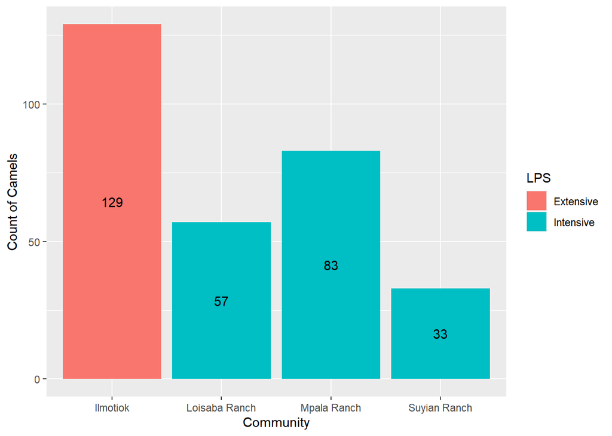

### Counts and Percentages of E.coli Isolated from all the camels This table counts and percentages of E.coli isolates in Extensive/Intensive location/Livestock procuction system

E.coli recovered from each of the LPS

| mo | Extensive | Intensive |
| --- | --- | --- |
| Escherichia coli | 39.71% (54) | 60.29% (82) |
| Others | 45.18% (75) | 54.82% (91) |

[figure not shown]

### Counts and percentages of the number of camels (female and male) from each livestock production system

Camels(Female and Male) from each of the LPS

| Gender | Extensive | Intensive |
| --- | --- | --- |
| Female | 48.40% (106) | 51.60% (113) |
| Male | 27.71% (23) | 72.29% (60) |

Antibiotic Susceptability Intermediate and Resistance

| antibiotic | S | I | R |
| --- | --- | --- | --- |
| Amoxicillin/clavulanic acid | 0.9926471 | 0.0073529 | 0.0000000 |
| Ampicillin | 0.8602941 | 0.0514706 | 0.0882353 |
| Cefaclor | 0.2426471 | 0.4779412 | 0.2794118 |
| Cefepime | 0.7500000 | 0.2205882 | 0.0294118 |
| Cefotaxime | 0.6176471 | 0.2205882 | 0.1617647 |
| Ceftazidime | 0.6985294 | 0.2279412 | 0.0735294 |
| Ceftriaxone | 0.9044118 | 0.0661765 | 0.0294118 |
| Cefuroxime | 0.8382353 | 0.1250000 | 0.0367647 |
| Chloramphenicol | 1.0000000 | 0.0000000 | 0.0000000 |
| Ciprofloxacin | 0.6102941 | 0.3750000 | 0.0147059 |
| Gentamicin | 0.9117647 | 0.0808824 | 0.0073529 |
| Norfloxacin | 1.0000000 | 0.0000000 | 0.0000000 |
| Spectinomycin | 0.8970588 | 0.0808824 | 0.0220588 |
| Tetracycline | 0.9338235 | 0.0147059 | 0.0514706 |
| Trimethoprim/sulfamethoxazole | 0.9632353 | 0.0073529 | 0.0294118 |

### Beta-lactams/penicillins

Beta-lactam antibiotics are one of the most commonly prescribed drug classes with numerous clinical indications.

From a biochemical point of view, these drugs have a common feature, which is the 3-carbon and 1-nitrogen ring (beta-lactam ring) that is highly reactive. This class includes:

Penicillins,Cephalosporins,Carbapenems,Monobactams,Beta-lactamase inhibitors

```
## Selecting beta-lactams/penicillins: column 'AMC' (amoxicillin/clavulanic
##                                     acid), column 'AMP' (ampicillin), column 'OXA' (oxacillin), column 'TEM'
##                                     (temocillin)
```

```
## NOTE: No antimicrobial agents of class cephalosporins (1st gen.) found
##       (such as cefazedone, ceftezole).
```

```
## Selecting cephalosporins (2nd gen.): column 'CEC' (cefaclor), column 'CXM'
##                                      (cefuroxime)
```

```
## NOTE: No antimicrobial agents of class carbapenems found (such as
##       imipenem/relebactam, razupenem).
```

Beta-lactams/penicillins

| mo | AMC | AMP | OXA | TEM | CEC | CXM |
| --- | --- | --- | --- | --- | --- | --- |
| Escherichia coli | S | S | NEG | NEG | I | S |
| Escherichia coli | S | S | NEG | NEG | R | S |
| Escherichia coli | S | S | NEG | POS | R | S |
| Escherichia coli | I | R | NEG | POS | R | S |
| Escherichia coli | S | S | NEG | NEG | I | S |
| Escherichia coli | S | I | NEG | NEG | R | I |
| Escherichia coli | S | S | NEG | NEG | I | S |
| Escherichia coli | S | S | NEG | NEG | I | S |
| Escherichia coli | S | R | NEG | NEG | I | S |
| Escherichia coli | S | S | NEG | NEG | I | S |
| Escherichia coli | S | S | NEG | NEG | R | S |
| Escherichia coli | S | R | NEG | POS | R | I |
| Escherichia coli | S | S | NEG | NEG | R | S |
| Escherichia coli | S | S | NEG | NEG | R | S |
| Escherichia coli | S | S | NEG | NEG | R | S |
| Escherichia coli | S | R | NEG | NEG | I | I |
| Escherichia coli | S | S | NEG | NEG | I | S |
| Escherichia coli | S | S | NEG | NEG | I | S |
| Escherichia coli | S | I | NEG | NEG | R | S |
| Escherichia coli | S | S | NEG | NEG | R | S |
| Escherichia coli | S | S | NEG | NEG | R | S |
| Escherichia coli | S | S | NEG | POS | R | S |
| Escherichia coli | S | R | NEG | NEG | R | I |
| Escherichia coli | S | S | NEG | NEG | I | S |
| Escherichia coli | S | S | NEG | NEG | I | S |
| Escherichia coli | S | S | NEG | NEG | I | S |
| Escherichia coli | S | S | NEG | NEG | R | S |
| Escherichia coli | S | S | NEG | NEG | R | S |
| Escherichia coli | S | I | NEG | POS | I | S |
| Escherichia coli | S | S | NEG | NEG | I | S |

[output cut: 106 more lines]

### Resisitance

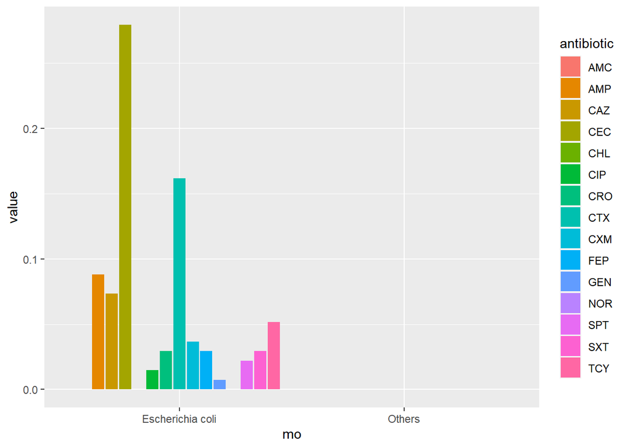

Comparision of Livestock Production system with their resistant to all antibiotics

| LPS | interpretation | AMC | AMP | CAZ | CEC | CHL | CIP | CRO | CTX | CXM | FEP | GEN | NOR | SPT | SXT | TCY |
| --- | --- | --- | --- | --- | --- | --- | --- | --- | --- | --- | --- | --- | --- | --- | --- | --- |
| Extensive | SI | 1 | 0.9259259 | 0.9074074 | 0.6666667 | 1 | 1.0000000 | 0.9814815 | 0.8333333 | 0.9814815 | 0.9814815 | 0.9814815 | 1 | 0.9814815 | 0.9814815 | 1.0000000 |
| Extensive | R | 0 | 0.0740741 | 0.0925926 | 0.3333333 | 0 | 0.0000000 | 0.0185185 | 0.1666667 | 0.0185185 | 0.0185185 | 0.0185185 | 0 | 0.0185185 | 0.0185185 | 0.0000000 |
| Intensive | SI | 1 | 0.9024390 | 0.9390244 | 0.7560976 | 1 | 0.9756098 | 0.9634146 | 0.8414634 | 0.9512195 | 0.9634146 | 1.0000000 | 1 | 0.9756098 | 0.9634146 | 0.9146341 |
| Intensive | R | 0 | 0.0975610 | 0.0609756 | 0.2439024 | 0 | 0.0243902 | 0.0365854 | 0.1585366 | 0.0487805 | 0.0365854 | 0.0000000 | 0 | 0.0243902 | 0.0365854 | 0.0853659 |

### Multdrug Resistance Organisms MDR

Multdrug Resistance Organisms MDR

| item | count | percent | cum_count | cum_percent |
| --- | --- | --- | --- | --- |
| Negative | 296 | 0.9801325 | 296 | 0.9801325 |
| Multi-drug-resistant (MDR) | 6 | 0.0198675 | 302 | 1.0000000 |

[output not shown]